# Chapter 6 - Linear Model Selection and Regularization - Lab 1 - Subset Selection Methods

# Chapter 6 - Linear Model Selection and Regularization - Lab 1 - Subset Selection Methods

## Best Subset Selection

Here we apply the best subset selection approach to the **Hitters** data. We wish to predict a baseball player’s **Salary** on the basis of various statistics associated with performance in the previous uear. First of all, we note that **Salary** variable is missing for some of the players. The **is.na()** function can be used to identify the missing observations. It returns a vector of the same length as the input vector, with a **TRUE** for any elements that are missing, and a **FALSE** for non-missing elements. The **sum()** function can then be used to count all of the missing elements.

```r
# fix(Hitters)
names(Hitters)
```

```
##  [1] "AtBat"     "Hits"      "HmRun"     "Runs"      "RBI"       "Walks"
##  [7] "Years"     "CAtBat"    "CHits"     "CHmRun"    "CRuns"     "CRBI"
## [13] "CWalks"    "League"    "Division"  "PutOuts"   "Assists"   "Errors"
## [19] "Salary"    "NewLeague"
```

```r
dim(Hitters)
```

```
## [1] 322  20
```

```r
sum(is.na(Hitters$Salary))
```

```
## [1] 59
```

Hence we see that **Salary** is missing for 59 players. The **na.omit()** function removes all of the rows that have missing values in any variable.

```r
Hitters = na.omit(Hitters)
dim(Hitters)
```

```
## [1] 263  20
```

```r
sum(is.na(Hitters$Salary))
```

```
## [1] 0
```

The **regsubsets()** function (part of the **leaps** library) performs best subset selection by udentifying the best model that contains a given number of predictors, where *best* is quantified using RSS. The syntax is the same as for **lm()**. The **summary()** command outputs the best set of variables for each model size.

```r
library(leaps)
regfit.full = regsubsets(Salary~., Hitters)
summary(regfit.full)
```

```
## Subset selection object
## Call: regsubsets.formula(Salary ~ ., Hitters)
## 19 Variables  (and intercept)
##            Forced in Forced out
## AtBat          FALSE      FALSE
## Hits           FALSE      FALSE
## HmRun          FALSE      FALSE
## Runs           FALSE      FALSE
## RBI            FALSE      FALSE
## Walks          FALSE      FALSE
## Years          FALSE      FALSE
## CAtBat         FALSE      FALSE
## CHits          FALSE      FALSE
## CHmRun         FALSE      FALSE
## CRuns          FALSE      FALSE
## CRBI           FALSE      FALSE
## CWalks         FALSE      FALSE
## LeagueN        FALSE      FALSE
## DivisionW      FALSE      FALSE
## PutOuts        FALSE      FALSE
## Assists        FALSE      FALSE
## Errors         FALSE      FALSE
## NewLeagueN     FALSE      FALSE
## 1 subsets of each size up to 8
## Selection Algorithm: exhaustive
##          AtBat Hits HmRun Runs RBI Walks Years CAtBat CHits CHmRun CRuns CRBI
## 1  ( 1 ) " "   " "  " "   " "  " " " "   " "   " "    " "   " "    " "   "*"
## 2  ( 1 ) " "   "*"  " "   " "  " " " "   " "   " "    " "   " "    " "   "*"
## 3  ( 1 ) " "   "*"  " "   " "  " " " "   " "   " "    " "   " "    " "   "*"
## 4  ( 1 ) " "   "*"  " "   " "  " " " "   " "   " "    " "   " "    " "   "*"
## 5  ( 1 ) "*"   "*"  " "   " "  " " " "   " "   " "    " "   " "    " "   "*"
## 6  ( 1 ) "*"   "*"  " "   " "  " " "*"   " "   " "    " "   " "    " "   "*"
## 7  ( 1 ) " "   "*"  " "   " "  " " "*"   " "   "*"    "*"   "*"    " "   " "
## 8  ( 1 ) "*"   "*"  " "   " "  " " "*"   " "   " "    " "   "*"    "*"   " "
##          CWalks LeagueN DivisionW PutOuts Assists Errors NewLeagueN
## 1  ( 1 ) " "    " "     " "       " "     " "     " "    " "
## 2  ( 1 ) " "    " "     " "       " "     " "     " "    " "
## 3  ( 1 ) " "    " "     " "       "*"     " "     " "    " "
## 4  ( 1 ) " "    " "     "*"       "*"     " "     " "    " "
## 5  ( 1 ) " "    " "     "*"       "*"     " "     " "    " "
## 6  ( 1 ) " "    " "     "*"       "*"     " "     " "    " "
## 7  ( 1 ) " "    " "     "*"       "*"     " "     " "    " "
## 8  ( 1 ) "*"    " "     "*"       "*"     " "     " "    " "
```

An asterisk indicates that a given variable is included in the corresponding model. For instance, this output indicates that the best two-variable model contains only **Hits** and **CRBI**. By default, **regsubsets()** only reports results up to the best eight-variable model. But the **nvmax** option can be used in order to return as many variables as are desired. Here we fit up to a 19-variable model.

```r
regfit.full = regsubsets(Salary~., data=Hitters, nvmax=19)
reg.summary = summary(regfit.full)
```

The **summary()** function also returns R^2, RSS, adjusted R^2, Cp,, and BIC. We can examine these to try to select the *best* overall model.

```r
names(reg.summary)
```

```
## [1] "which"  "rsq"    "rss"    "adjr2"  "cp"     "bic"    "outmat" "obj"
```

For instance, we see that the R^2 statistic increases from 32%, when only one variable is included in the model, to almost 55%, when all variables are included. As expected, the R^2 statistic increases monotonically as more variables are included.

```r
reg.summary$rsq
```

```
##  [1] 0.3214501 0.4252237 0.4514294 0.4754067 0.4908036 0.5087146 0.5141227
##  [8] 0.5285569 0.5346124 0.5404950 0.5426153 0.5436302 0.5444570 0.5452164
## [15] 0.5454692 0.5457656 0.5459518 0.5460945 0.5461159
```

Plotting RSS, adjusted R^2, Cp, and BIC for all of the models at once will help us decide which model to select. Note the **type=“1”** option tells R to connect the plotted points with lines.

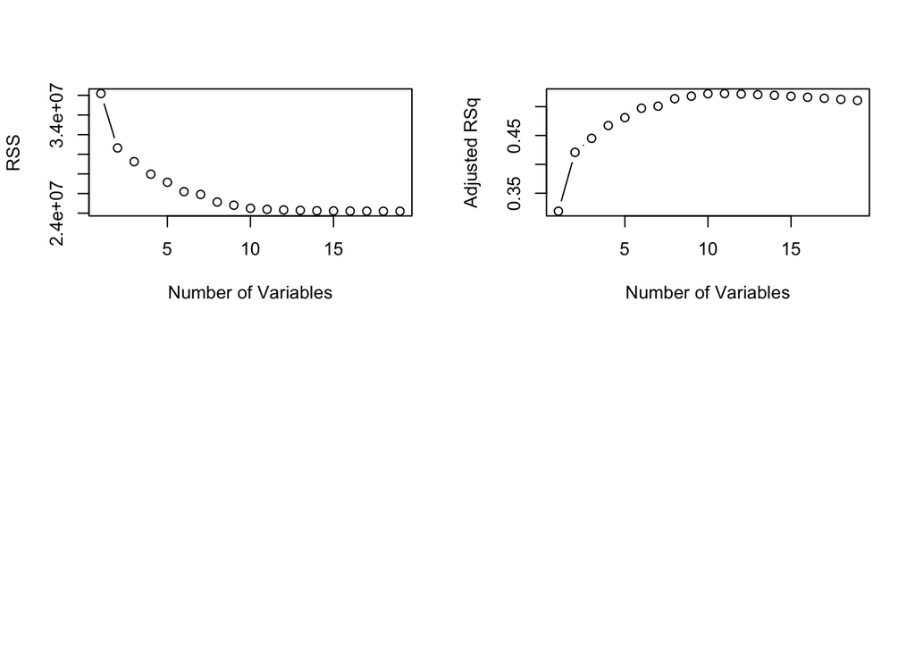

```r
par(mfrow=c(2, 2))
plot(reg.summary$rss, xlab="Number of Variables", ylab="RSS", type="b")
plot(reg.summary$adjr2, xlab="Number of Variables", ylab="Adjusted RSq", type="b")
```

```r
plot(reg.summary$adjr2, xlab="Number of Variables", ylab="Adjusted RSq", type="b")
which.max(reg.summary$adjr2)
```

```
## [1] 11
```

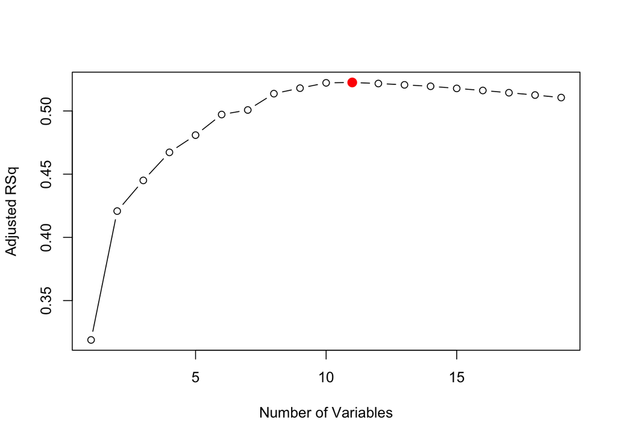

```r
points(11, reg.summary$adjr2[11], col="red", cex=2, pch=20)
```

In a similar fashion we can plot the Cp and BIC statistics, and indicate the models with the smallest statistic using **which.min()**.

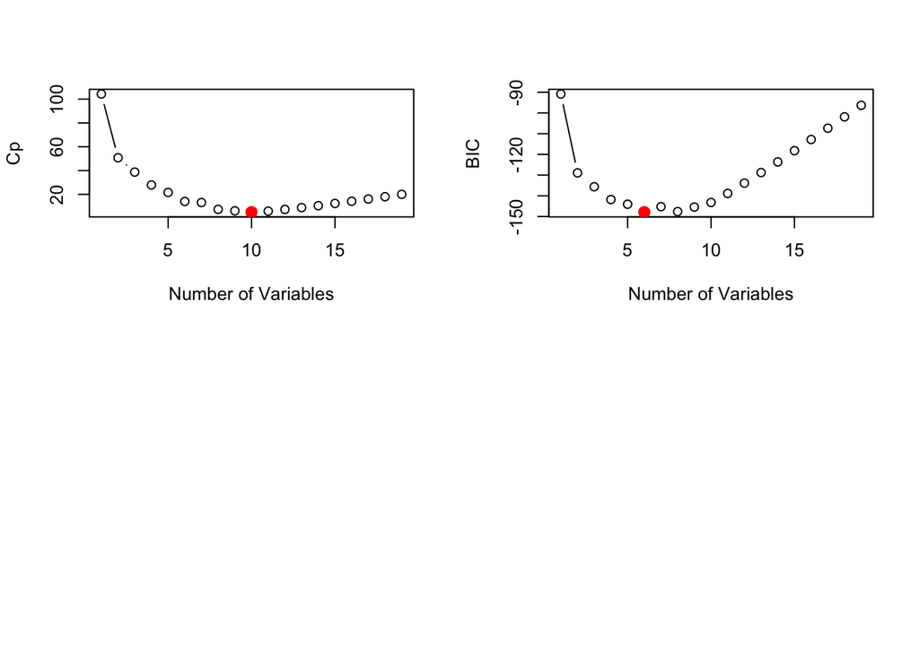

```r
par(mfrow=c(2, 2))
cp_min_index = which.min(reg.summary$cp)
plot(reg.summary$cp, xlab="Number of Variables", ylab="Cp", type="b")
points(cp_min_index, reg.summary$cp[cp_min_index], col="red", cex=2, pch=20)
bic_min_index = which.min(reg.summary$bic)
plot(reg.summary$bic, xlab="Number of Variables", ylab="BIC", type="b")
points(bic_min_index, reg.summary$bic[bic_min_index], col="red", cex=2, pch=20)
```

The **regsubsets()** function has a built-in **plot()** command which can be used to display the selected variables for the best model with a given number of predictors, ranked according to the BIC, Cp, adjusted R^2, or AIC. To find out more about this function, type **?plot.regsubsets**.

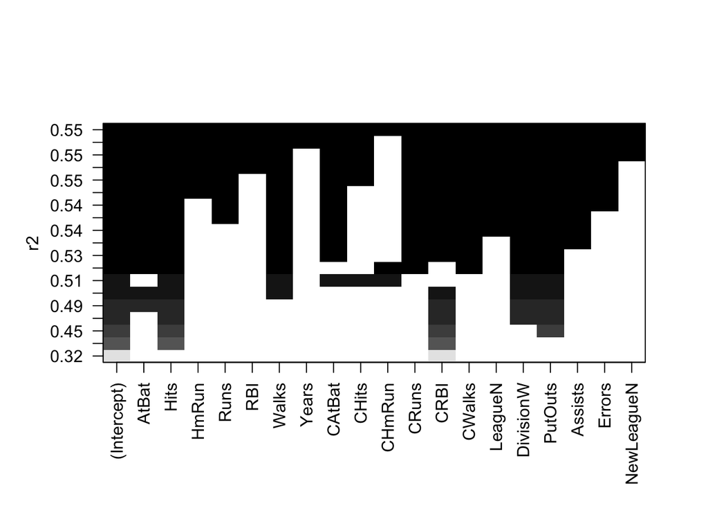

```r
plot(regfit.full, scale="r2")
```

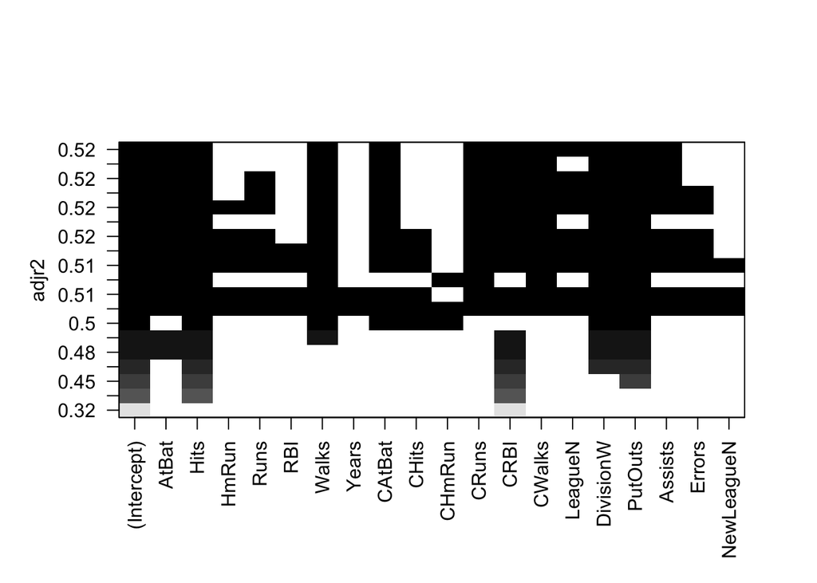

```r
plot(regfit.full, scale="adjr2")
```

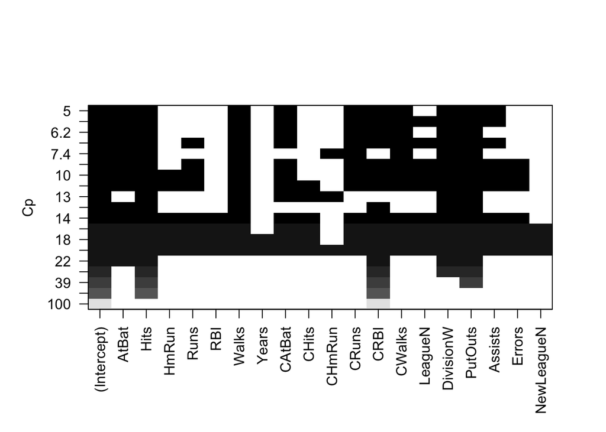

```r
plot(regfit.full, scale="Cp")
```

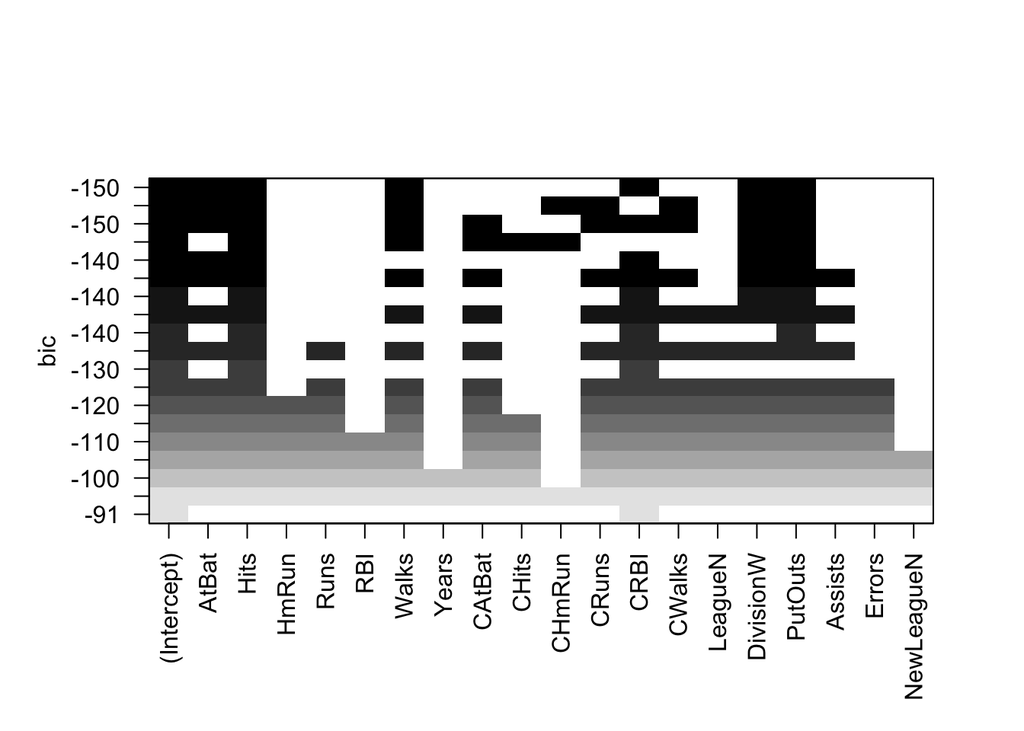

```r
plot(regfit.full, scale="bic")
```

The top row of each plot contains a black square for each variable selected according to the optimal model associated with that statistic. For instance, we see that several models share a BIC close to -150. However, the model with the lowest BIC is the six-variable model that contains only **AtBat**, **Hits**, **Walks**, **CRBI**, **DivisionW**, and **PutOuts**. We can use the **coef()** function to see the cpefficient estimates associated with this model.

```r
coef(regfit.full, 6)
```

```
##  (Intercept)        AtBat         Hits        Walks         CRBI    DivisionW
##   91.5117981   -1.8685892    7.6043976    3.6976468    0.6430169 -122.9515338
##      PutOuts
##    0.2643076
```